# Trabajo Especializacion V1.0.0

Ignacio Chiapella

## Librerias

```r
library(cluster)
library(broom)
library(glmnet)
library(modelr)
library(ggplot2)
library(cowplot)



library(mongolite)
library(ggmap)
library(dplyr)
library(sp)
library(lubridate)
library(tidyr)
library(reshape2)
library(stringr)
```

## Modelo lineal

```r
preciosModelo <- read.csv(file = '/home/ignacio/datos/facultad/repos/tpEspecializacion/data/preciosModelo.csv')
preciosModelo = select (preciosModelo,-c(X,barrio,sucursal))
```

### Modelo lineal simple para explicar el precio en función de la bandera supermercado

```r
# banderaDescripcion + medicion + barrio + banderaDescripcion + pVentasC + mCuadradoC
lm_precio2bandera = lm(formula = precio~banderaDescripcion, data=preciosModelo)
lm_precio2medicion = lm(formula = precio~medicion, data=preciosModelo)
#lm_precio2barrio = lm(formula = precio~barrio, data=precios)
```

```r
summary(lm_precio2bandera)
```

```
Call:
lm(formula = precio ~ banderaDescripcion, data = preciosModelo)

Residuals:
   Min     1Q Median     3Q    Max
-82.83 -38.71 -18.17  14.82 617.19

Coefficients:
                                         Estimate Std. Error t value Pr(>|t|)
(Intercept)                               81.1674     0.1042 778.923  < 2e-16 ***
banderaDescripcionDisco                    5.0769     0.1752  28.973  < 2e-16 ***
banderaDescripcionExpress                 -5.3563     0.2768 -19.354  < 2e-16 ***
banderaDescripcionHipermercado Carrefour  -3.8789     0.3155 -12.294  < 2e-16 ***
banderaDescripcionJOSIMAR SUPERMERCADOS   -5.3012     0.8146  -6.507 7.65e-11 ***
banderaDescripcionJumbo                    4.7310     0.3405  13.894  < 2e-16 ***
banderaDescripcionMarket                  -3.9604     0.1744 -22.714  < 2e-16 ***
banderaDescripcionMi Changomas           -10.5035     1.0131 -10.368  < 2e-16 ***
banderaDescripcionSupermercados DIA       -4.6258     0.2690 -17.198  < 2e-16 ***
banderaDescripcionVea                      1.9413     0.2553   7.605 2.85e-14 ***
---
Signif. codes:  0 ‘***’ 0.001 ‘**’ 0.01 ‘*’ 0.05 ‘.’ 0.1 ‘ ’ 1

Residual standard error: 65.55 on 1146544 degrees of freedom
Multiple R-squared:  0.003011,  Adjusted R-squared:  0.003003
F-statistic: 384.7 on 9 and 1146544 DF,  p-value: < 2.2e-16
```

```r
#coef(lm_precio2bandera)
```

```r
summary(lm_precio2medicion)
```

```
Call:
lm(formula = precio ~ medicion, data = preciosModelo)

Residuals:
   Min     1Q Median     3Q    Max
-81.69 -38.51 -18.25  15.34 610.63

Coefficients:
            Estimate Std. Error t value Pr(>|t|)
(Intercept) 75.23229    0.13200  569.95   <2e-16 ***
medicion     1.01898    0.02121   48.03   <2e-16 ***
---
Signif. codes:  0 ‘***’ 0.001 ‘**’ 0.01 ‘*’ 0.05 ‘.’ 0.1 ‘ ’ 1

Residual standard error: 65.58 on 1146552 degrees of freedom
Multiple R-squared:  0.002008,  Adjusted R-squared:  0.002007
F-statistic:  2307 on 1 and 1146552 DF,  p-value: < 2.2e-16
```

```r
glance(lm_precio2bandera)
```

| r.squared | adj.r.squared | sigma | statistic | p.value | df | logLik | AIC | BIC | deviance | df.residual | nobs |
| --- | --- | --- | --- | --- | --- | --- | --- | --- | --- | --- | --- |
| 0.003010854 | 0.003003028 | 65.54811 | 384.7224 | 0 | 9 | -6422673 | 12845368 | 12845499 | 4926188655 | 1146544 | 1146554 |

```r
glance(lm_precio2medicion)
```

| r.squared | adj.r.squared | sigma | statistic | p.value | df | logLik | AIC | BIC | deviance | df.residual | nobs |
| --- | --- | --- | --- | --- | --- | --- | --- | --- | --- | --- | --- |
| 0.002008311 | 0.002007441 | 65.58083 | 2307.267 | 0 | 1 | -6423249 | 12846504 | 12846540 | 4931142285 | 1146552 | 1146554 |

```r
# banderaDescripcion + sucursalTipo + medicion + pVentasC + mCuadradoC
lm_precioMultiple = lm(precio ~ banderaDescripcion + sucursalTipo + medicion + pVentasC + mCuadradoC , data=preciosModelo)
```

```r
# medicion - barrio - sucursalTipo - banderaDescripcion
summary(lm_precioMultiple)
```

```
Call:
lm(formula = precio ~ banderaDescripcion + sucursalTipo + medicion +
    pVentasC + mCuadradoC, data = preciosModelo)

Residuals:
   Min     1Q Median     3Q    Max
-87.35 -38.54 -17.93  15.02 615.90

Coefficients:
                                         Estimate Std. Error t value Pr(>|t|)
(Intercept)                              75.89405    0.20196 375.787  < 2e-16 ***
banderaDescripcionDisco                   5.38072    0.20149  26.705  < 2e-16 ***
banderaDescripcionExpress                -4.89703    0.29251 -16.741  < 2e-16 ***
banderaDescripcionHipermercado Carrefour -4.05007    0.34297 -11.809  < 2e-16 ***
banderaDescripcionJOSIMAR SUPERMERCADOS  -4.87521    0.83306  -5.852 4.85e-09 ***
banderaDescripcionJumbo                   4.89757    0.34393  14.240  < 2e-16 ***
banderaDescripcionMarket                 -3.77411    0.18581 -20.312  < 2e-16 ***
banderaDescripcionMi Changomas           -9.39337    1.02765  -9.141  < 2e-16 ***
banderaDescripcionSupermercados DIA      -4.28939    0.28543 -15.028  < 2e-16 ***
banderaDescripcionVea                     2.29485    0.26545   8.645  < 2e-16 ***
sucursalTipoSupermercado                 -0.50046    0.17477  -2.864 0.004188 **
medicion                                  1.01813    0.02119  48.052  < 2e-16 ***
pVentasCbajo                              0.34679    0.26761   1.296 0.195011
pVentasCmedio                             0.12908    0.17839   0.724 0.469339
mCuadradoCbajo                            0.02740    0.18938   0.145 0.884940
mCuadradoCmedio                          -0.52743    0.14472  -3.645 0.000268 ***
---
Signif. codes:  0 ‘***’ 0.001 ‘**’ 0.01 ‘*’ 0.05 ‘.’ 0.1 ‘ ’ 1

Residual standard error: 65.48 on 1146538 degrees of freedom
Multiple R-squared:  0.005041,  Adjusted R-squared:  0.005028
F-statistic: 387.2 on 15 and 1146538 DF,  p-value: < 2.2e-16
```

### Analisis modelo compuesto

#### Analisis Residuo

```r
precioMultiple_resid = augment(lm_precioMultiple)
precioMultiple_resid
```

| precio | banderaDescripcion | sucursalTipo | medicion | pVentasC | mCuadradoC | .fitted | .resid | .std.resid | .hat | .sigma | .cooksd |
| --- | --- | --- | --- | --- | --- | --- | --- | --- | --- | --- | --- |
| 329.99 | COTO CICSA | Supermercado | 6 | bajo | alto | 81.84918 | 248.1408164 | 3.789517648 | 2.069517e-05 | 65.48114 | 1.857487e-05 |
| 53.39 | COTO CICSA | Supermercado | 6 | bajo | alto | 81.84918 | -28.4591836 | -0.434618456 | 2.069517e-05 | 65.48155 | 2.443286e-07 |
| 76.99 | COTO CICSA | Supermercado | 6 | bajo | alto | 81.84918 | -4.8591836 | -0.074207711 | 2.069517e-05 | 65.48155 | 7.122886e-09 |
| 181.99 | COTO CICSA | Supermercado | 6 | bajo | alto | 81.84918 | 100.1408164 | 1.529314671 | 2.069516e-05 | 65.48148 | 3.025183e-06 |
| 46.09 | COTO CICSA | Supermercado | 6 | bajo | alto | 81.84918 | -35.7591836 | -0.546101441 | 2.069517e-05 | 65.48154 | 3.857488e-07 |
| 47.19 | COTO CICSA | Supermercado | 6 | bajo | alto | 81.84918 | -34.6591836 | -0.529302635 | 2.069517e-05 | 65.48154 | 3.623815e-07 |
| 70.25 | COTO CICSA | Supermercado | 6 | bajo | alto | 81.84918 | -11.5991836 | -0.177138577 | 2.069517e-05 | 65.48155 | 4.058674e-08 |
| 42.00 | COTO CICSA | Supermercado | 6 | bajo | alto | 81.84918 | -39.8491836 | -0.608562455 | 2.069517e-05 | 65.48154 | 4.790361e-07 |
| 46.99 | COTO CICSA | Supermercado | 6 | bajo | alto | 81.84918 | -34.8591836 | -0.532356963 | 2.069517e-05 | 65.48154 | 3.665758e-07 |
| 258.60 | COTO CICSA | Supermercado | 6 | bajo | alto | 81.84918 | 176.7508164 | 2.699275144 | 2.069517e-05 | 65.48134 | 9.424367e-06 |

[output cut: 990 more lines]

```r
#El promedio de los residuos debe ser un numero muy cercano a cero
mean(precioMultiple_resid$.resid)
```

```
[1] 1.106236e-11
```

Como se puede apreciar el valor obtenido del promedio de todos los residuos, es un numero cercano a cero.

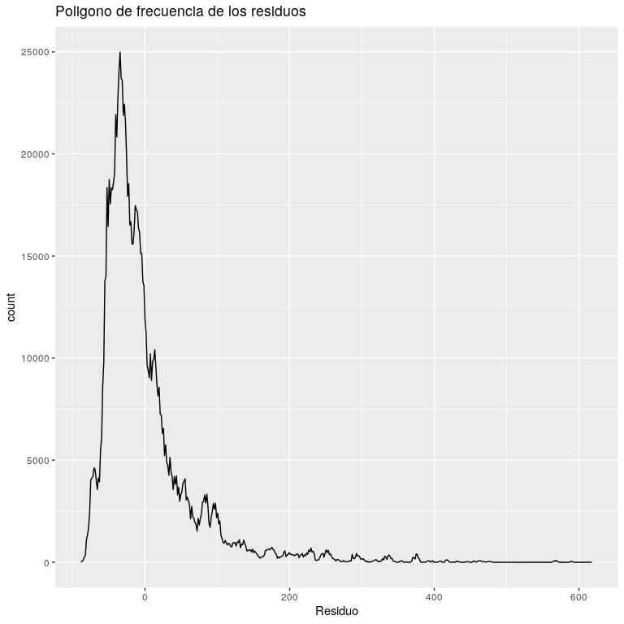

```r
ggplot(precioMultiple_resid, aes(precioMultiple_resid$.resid)) +
  geom_freqpoly(binwidth = 1.5)+
  labs(fill = "precioMultiple_resid$.resid", title = "Poligono de frecuencia de los residuos", x = "Residuo", y = "count")
```

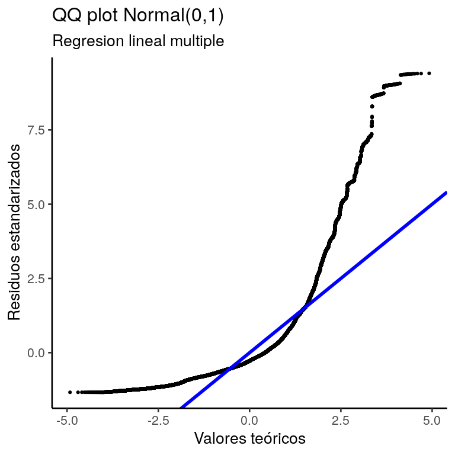

```r
ggplot(precioMultiple_resid, aes(sample= .std.resid))+
  stat_qq()+
  geom_abline(colour = "blue", size=2)+
  labs(title = "QQ plot Normal(0,1)",subtitle = "Regresion lineal multiple", x = "Valores teóricos", y = "Residuos estandarizados")+
  theme_classic(base_size = 20)
```

Se quiere validar, si los residuos siguien una distribucion teorica, N(0,1). Como podemos ver el modelo en los extremos tiende a alejarse de la distribucion Normal, por lo que puedo concluir que el modelo no esta bien definido.

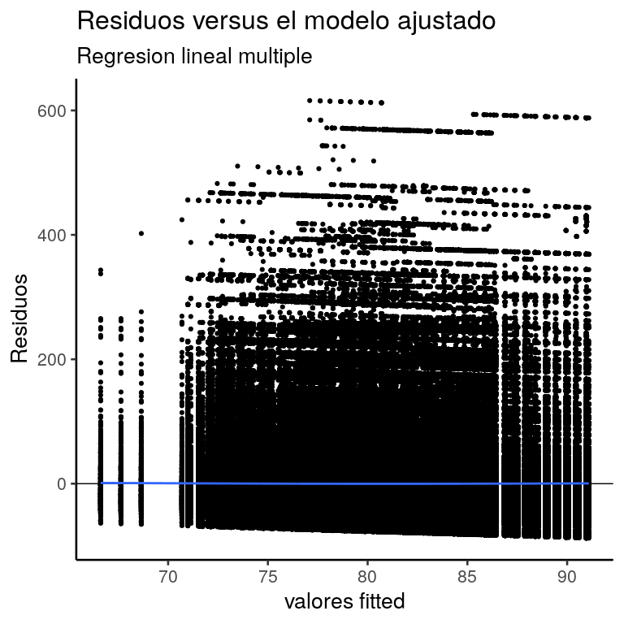

```r
ggplot(precioMultiple_resid, aes(.fitted, .resid)) +
  geom_point()+
  geom_hline(yintercept = 0) +
  geom_smooth(se = FALSE)+
  labs(title = "Residuos versus el modelo ajustado",subtitle = "Regresion lineal multiple", x = "valores fitted", y =   "Residuos")+
  theme_classic(base_size = 20)
```

Otro caso interesando para estudiar, es si los residuos tienen o no una estructura definida. Lo que se obseva es una clara estructura en el medio del grafico, esto esta indicando que una parte sistemática del fenómeno que se esta perdiendo, lo cual indica que el modelo no esta funcionando como se esperaria.

```r
# banderaDescripcion + sucursalTipo + medicion + banderaDescripcion + pVentasC + mCuadradoC
preciosModelo_log                    = preciosModelo
preciosModelo_log$precio             = log(preciosModelo_log$precio)
preciosModelo_log$medicion           = log(preciosModelo_log$medicion)

lm_precioMultiple_log = lm(precio ~ banderaDescripcion + sucursalTipo + medicion  + pVentasC + mCuadradoC , data=preciosModelo_log)
```

```r
summary(lm_precioMultiple_log)
```

```
Call:
lm(formula = precio ~ banderaDescripcion + sucursalTipo + medicion +
    pVentasC + mCuadradoC, data = preciosModelo_log)

Residuals:
     Min       1Q   Median       3Q      Max
-3.09431 -0.40124 -0.00623  0.41589  2.43126

Coefficients:
                                           Estimate Std. Error  t value Pr(>|t|)
(Intercept)                               4.0812515  0.0022879 1783.825  < 2e-16 ***
banderaDescripcionDisco                   0.0615033  0.0021787   28.230  < 2e-16 ***
banderaDescripcionExpress                -0.0516603  0.0031628  -16.334  < 2e-16 ***
banderaDescripcionHipermercado Carrefour -0.0489795  0.0037083  -13.208  < 2e-16 ***
banderaDescripcionJOSIMAR SUPERMERCADOS  -0.0282972  0.0090073   -3.142  0.00168 **
banderaDescripcionJumbo                   0.0580706  0.0037187   15.616  < 2e-16 ***
banderaDescripcionMarket                 -0.0463983  0.0020091  -23.095  < 2e-16 ***
banderaDescripcionMi Changomas           -0.0691800  0.0111116   -6.226 4.79e-10 ***
banderaDescripcionSupermercados DIA      -0.0381283  0.0030862  -12.354  < 2e-16 ***
banderaDescripcionVea                     0.0280666  0.0028702    9.778  < 2e-16 ***
sucursalTipoSupermercado                 -0.0055061  0.0018896   -2.914  0.00357 **
medicion                                  0.0473387  0.0009461   50.035  < 2e-16 ***
pVentasCbajo                              0.0033629  0.0028935    1.162  0.24514
pVentasCmedio                             0.0005203  0.0019288    0.270  0.78735
mCuadradoCbajo                           -0.0009798  0.0020476   -0.479  0.63229
mCuadradoCmedio                          -0.0064328  0.0015648   -4.111 3.94e-05 ***
---
Signif. codes:  0 ‘***’ 0.001 ‘**’ 0.01 ‘*’ 0.05 ‘.’ 0.1 ‘ ’ 1

Residual standard error: 0.708 on 1146538 degrees of freedom
Multiple R-squared:  0.00547,   Adjusted R-squared:  0.005457
F-statistic: 420.4 on 15 and 1146538 DF,  p-value: < 2.2e-16
```

```r
lm_precioMultiple_log_resid = augment(lm_precioMultiple_log)
lm_precioMultiple_log_resid
```

| precio | banderaDescripcion | sucursalTipo | medicion | pVentasC | mCuadradoC | .fitted | .resid | .std.resid | .hat | .sigma | .cooksd |
| --- | --- | --- | --- | --- | --- | --- | --- | --- | --- | --- | --- |
| 5.799062 | COTO CICSA | Supermercado | 1.791759 | bajo | alto | 4.163928 | 1.635134473 | 2.309476532 | 2.080068e-05 | 0.7080169 | 6.934156e-06 |
| 3.977623 | COTO CICSA | Supermercado | 1.791759 | bajo | alto | 4.163928 | -0.186304416 | -0.263137793 | 2.080068e-05 | 0.7080185 | 9.001874e-08 |
| 4.343676 | COTO CICSA | Supermercado | 1.791759 | bajo | alto | 4.163928 | 0.179747665 | 0.253876989 | 2.080068e-05 | 0.7080185 | 8.379405e-08 |
| 5.203952 | COTO CICSA | Supermercado | 1.791759 | bajo | alto | 4.163928 | 1.040023862 | 1.468937725 | 2.080068e-05 | 0.7080179 | 2.805261e-06 |
| 3.830596 | COTO CICSA | Supermercado | 1.791759 | bajo | alto | 4.163928 | -0.333331871 | -0.470800506 | 2.080068e-05 | 0.7080185 | 2.881644e-07 |
| 3.854182 | COTO CICSA | Supermercado | 1.791759 | bajo | alto | 4.163928 | -0.309745872 | -0.437487459 | 2.080068e-05 | 0.7080185 | 2.488271e-07 |
| 4.252060 | COTO CICSA | Supermercado | 1.791759 | bajo | alto | 4.163928 | 0.088132430 | 0.124478924 | 2.080068e-05 | 0.7080185 | 2.014458e-08 |
| 3.737670 | COTO CICSA | Supermercado | 1.791759 | bajo | alto | 4.163928 | -0.426258260 | -0.602050454 | 2.080068e-05 | 0.7080184 | 4.712293e-07 |
| 3.849935 | COTO CICSA | Supermercado | 1.791759 | bajo | alto | 4.163928 | -0.313993065 | -0.443486227 | 2.080068e-05 | 0.7080185 | 2.556977e-07 |
| 5.555282 | COTO CICSA | Supermercado | 1.791759 | bajo | alto | 4.163928 | 1.391354588 | 1.965159951 | 2.080068e-05 | 0.7080173 | 5.020677e-06 |

[output cut: 990 more lines]

```r
mean(lm_precioMultiple_log_resid$.resid)
```

```
[1] 5.4611e-12
```

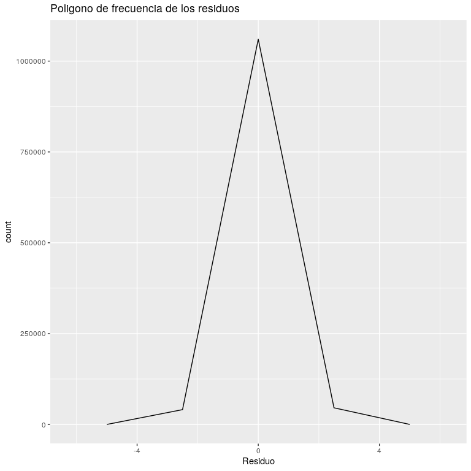

```r
ggplot(lm_precioMultiple_log_resid, aes(lm_precioMultiple_log_resid$.resid)) +
  geom_freqpoly(binwidth = 2.5)+
  labs(fill = "propiedades_resid$.resid", title = "Poligono de frecuencia de los residuos", x = "Residuo", y = "count")
```

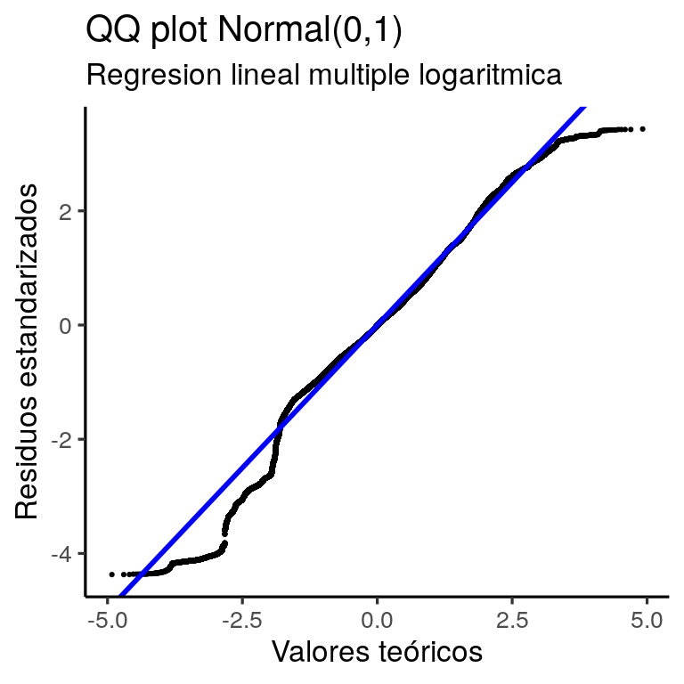

```r
ggplot(lm_precioMultiple_log_resid, aes(sample= .std.resid))+
  stat_qq()+
  geom_abline(colour = "blue", size=2)+
  labs(title = "QQ plot Normal(0,1)",subtitle = "Regresion lineal multiple logaritmica", x = "Valores teóricos", y = "Residuos estandarizados")+
  theme_classic(base_size = 25)
```

Lo que se obsera en este grafico, es que si bien en los extremos la tendencia es alejarse de la recta, los valores estan mucho mas pegados a ella que en el modelo anterior, lo mismo ocurre con los valores intermedios que estan practicamente sobre la recta. Por lo antes explicado, este modelo esta mejor definido que el anterior.

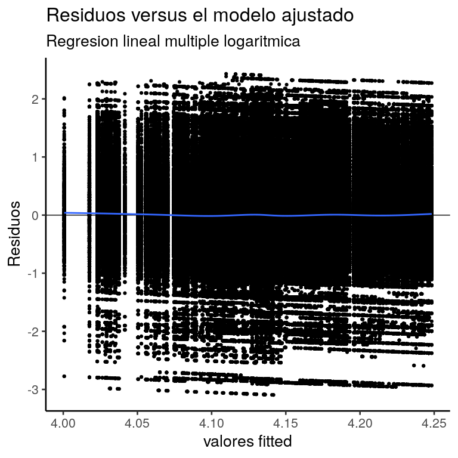

```r
ggplot(lm_precioMultiple_log_resid, aes(.fitted, .resid)) +
  geom_point()+
  geom_hline(yintercept = 0) +
  geom_smooth(se = FALSE)+
    labs(title = "Residuos versus el modelo ajustado",subtitle = "Regresion lineal multiple logaritmica", x = "valores fitted", y = "Residuos")+
  theme_classic(base_size = 20)
```

Si bien en este caso la diferencia no es tan notoria como en el analisis anterior, se puede apreciar que los residuos no estan formando una figura tan concentrada con en el caso no logaritmico, dando una mejora al modelo en este caso. Repasando el articulo sobre la aplicacion de logaritmos para el estudio, este nuevo modelo con logaritmos podria considerarse un hibrido entre un modelo log-nivel para las covariables que no se modificaron y un modelo log-log para aquellas que si lo fueron.

### Coeficientes estimados y sus p-valores asociados

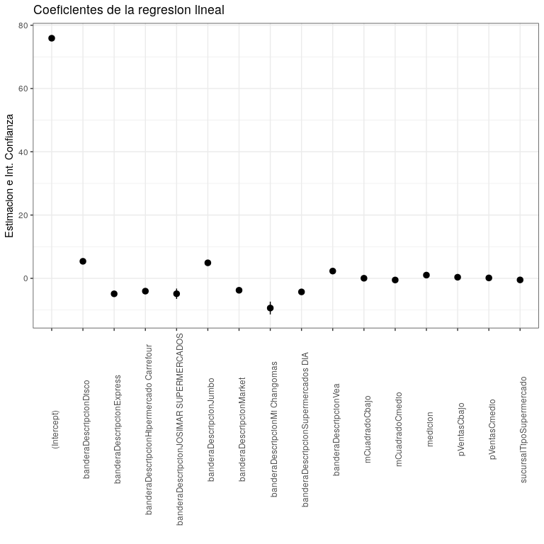

```r
lineal_coef= lm_precioMultiple %>% tidy(conf.int=TRUE)
lineal_coef_log= lm_precioMultiple_log %>% tidy(conf.int=TRUE)

ggplot(lineal_coef, aes(term, estimate))+
  geom_point()+
  geom_pointrange(aes(ymin = conf.low, ymax = conf.high))+
  labs(title = "Coeficientes de la regresion lineal", x="", y="Estimacion e Int. Confianza") +
  theme_bw() +
  theme(axis.text.x = element_text(angle=90))
```

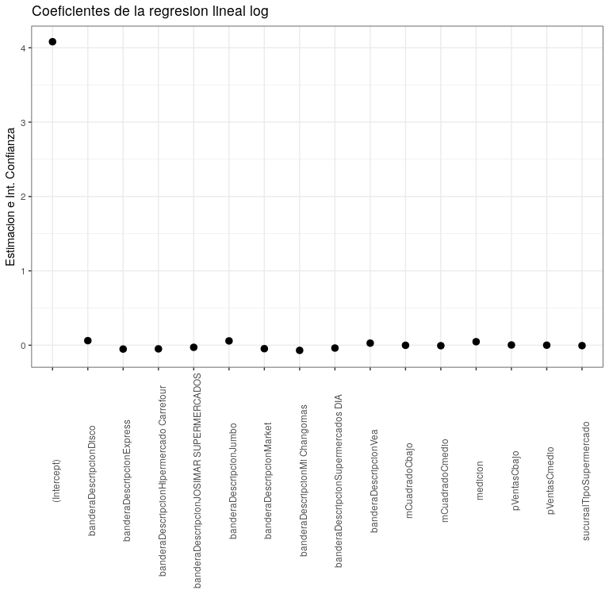

```r
ggplot(lineal_coef_log, aes(term, estimate))+
  geom_point()+
  geom_pointrange(aes(ymin = conf.low, ymax = conf.high))+
  labs(title = "Coeficientes de la regresion lineal log", x="", y="Estimacion e Int. Confianza") +
  theme_bw() +
  theme(axis.text.x = element_text(angle=90))
```

### P-Valor de los regresores

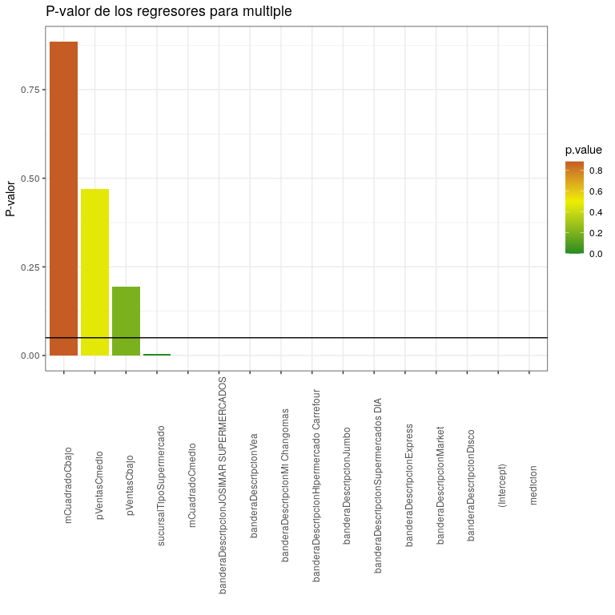

```r
ggplot(lineal_coef, aes(reorder(term, -p.value), p.value, fill=p.value))+
  geom_bar(stat = 'identity', aes(fill=p.value))+
  geom_hline(yintercept = 0.05) +
  labs(title = "P-valor de los regresores para multiple", x="", y="P-valor") +
  theme_bw() +
  theme(axis.text.x = element_text(angle=90)) +
  scale_fill_gradient2(high='firebrick', low = 'forestgreen', mid='yellow2',midpoint = 0.5 )
```

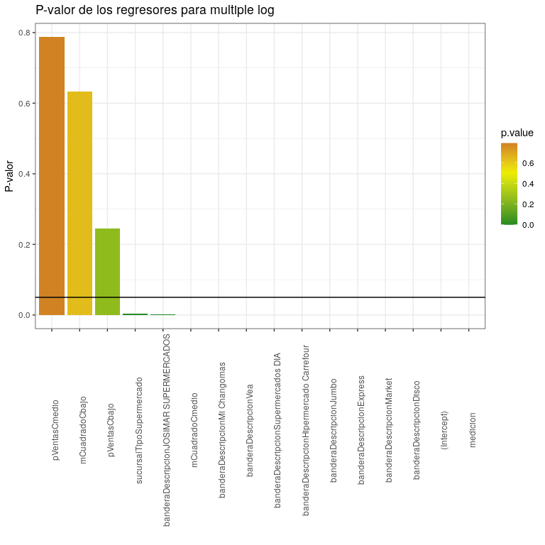

```r
ggplot(lineal_coef_log, aes(reorder(term, -p.value), p.value, fill=p.value))+
  geom_bar(stat = 'identity', aes(fill=p.value))+
  geom_hline(yintercept = 0.05) +
  labs(title = "P-valor de los regresores para multiple log", x="", y="P-valor") +
  theme_bw() +
  theme(axis.text.x = element_text(angle=90)) +
  scale_fill_gradient2(high='firebrick', low = 'forestgreen', mid='yellow2',midpoint = 0.5 )
```

### Evaluacion de ambos modelos

```r
multiple = lm_precioMultiple %>% glance() %>% select(r.squared, adj.r.squared, p.value)
multiple_log = lm_precioMultiple_log %>% glance() %>% select(r.squared, adj.r.squared, p.value)
bind_rows(multiple, multiple_log) %>% mutate(modelo= c('multiple', 'multiple_log'))
```

| r.squared | adj.r.squared | p.value | modelo |
| --- | --- | --- | --- |
| 0.005040559 | 0.005027542 | 0 | multiple |
| 0.005469563 | 0.005456552 | 0 | multiple_log |

```r
NA
```

### Ridge: α=0

### Lasso: α=1

```r
train_test <- preciosModelo %>% resample_partition(c(train=0.7,test=0.3))

precios_train <- train_test$train %>% as_tibble()
precios_test <- train_test$test %>% as_tibble()
```

## Lasso

```r
# Vector con los salarios
prod_precios = preciosModelo$precio
# Matriz con los regresores
prod_mtx = model.matrix(precio~ banderaDescripcion + sucursalTipo + medicion + pVentasC + mCuadradoC, data = preciosModelo)

# Modelo Lasso
lasso.mod=glmnet(x=prod_mtx, # Matriz de regresores
                 y=prod_precios, #Vector de la variable a predecir
                 alpha=1, # Indicador del tipo de regularizacion
                 standardize = F) # Que esta haciendo este parametro?

lasso_coef = lasso.mod %>% tidy()

lasso_coef
```

| term | step | estimate | lambda | dev.ratio |
| --- | --- | --- | --- | --- |
| (Intercept) | 1 | 8.084885e+01 | 8.493554454 | 0.0000000000 |
| (Intercept) | 2 | 8.034989e+01 | 7.739010486 | 0.0003409759 |
| (Intercept) | 3 | 7.989526e+01 | 7.051498124 | 0.0006240602 |
| (Intercept) | 4 | 7.948101e+01 | 6.425062466 | 0.0008590816 |
| (Intercept) | 5 | 7.910357e+01 | 5.854277626 | 0.0010542006 |
| (Intercept) | 6 | 7.875965e+01 | 5.334199737 | 0.0012161918 |
| (Intercept) | 7 | 7.844629e+01 | 4.860324134 | 0.0013506798 |
| (Intercept) | 8 | 7.816077e+01 | 4.428546334 | 0.0014623340 |
| (Intercept) | 9 | 7.790061e+01 | 4.035126484 | 0.0015550313 |
| (Intercept) | 10 | 7.766356e+01 | 3.676656969 | 0.0016319903 |

[output cut: 847 more lines]

```r
NA
```

### Grafico de coeficientes en funcion del lambda

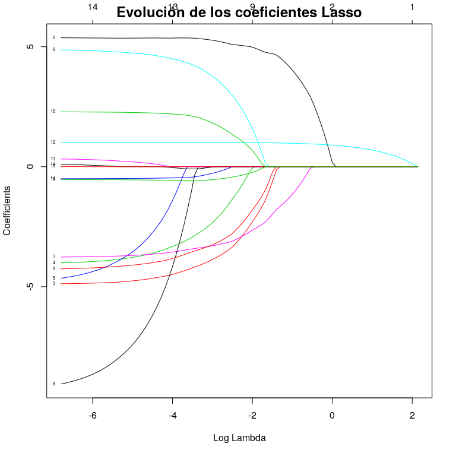

```r
plot(lasso.mod, xvar = "lambda", label = TRUE)
title(main = list("Evolución de los coeficientes Lasso",
                  cex = 1.5, col = "black", font = 10))
```

```r
#plot(lasso.mod)
```

Evolución de los coeficientes a medida que se incrementa λ. Los coeficientes se van haciendo más pequeños a medida que se incrementa el valor de λ.

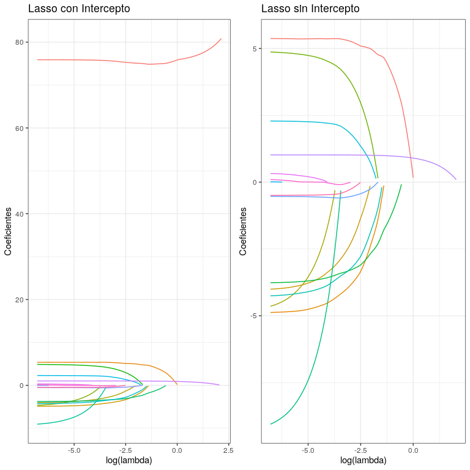

```r
# Graficos para los valores de lambda en ggplot.

g1=lasso_coef  %>% ggplot(., aes(log(lambda), estimate, group=term, color=term)) + geom_line() + theme_bw()  + theme(legend.position = 'none') +
  labs(title="Lasso con Intercepto",  y="Coeficientes")

g2=lasso_coef %>% filter(term!='(Intercept)') %>%
  ggplot(., aes(log(lambda), estimate, group=term, color=term)) + geom_line() + theme_bw()  + theme(legend.position = 'none') +
  labs(title="Lasso sin Intercepto", y="Coeficientes")

plot_grid(g1,g2)
```

### Cross Validation para LASSO

```r
lasso_cv=cv.glmnet(x=prod_mtx,y=prod_precios,alpha=1, standardize = T)
lasso_cv
```

```
Call:  cv.glmnet(x = prod_mtx, y = prod_precios, alpha = 1, standardize = T)

Measure: Mean-Squared Error

    Lambda Measure    SE Nonzero
min 0.0194    4288 19.71      14
1se 2.4424    4306 19.84       2
```

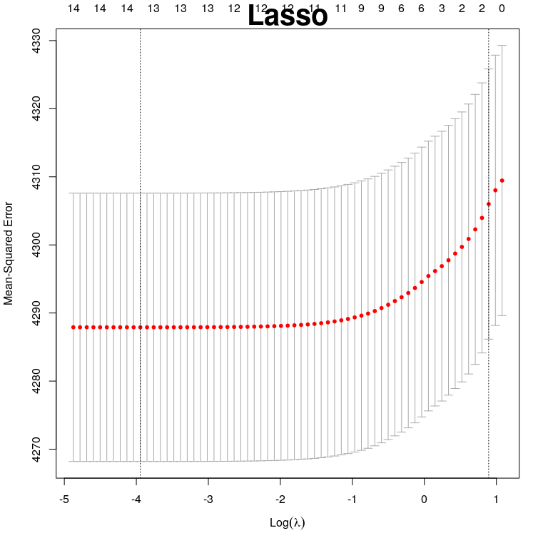

```r
plot(lasso_cv)
title(main = list("Lasso",
                  cex = 2.5, col = "black", font = 10))
```

El gráfico nos muestra la media del MSE con su limite superior e inferior y la cantidad de varaibles que sobreviven para cada valor de lambda.

```r
# Información de CV en dataframe con tidy
lasso_cv %>% tidy()
```

| lambda | estimate | std.error | conf.low | conf.high | nzero |
| --- | --- | --- | --- | --- | --- |
| 2.941904304 | 4309.452 | 19.84334 | 4289.609 | 4329.295 | 0 |
| 2.680553634 | 4308.017 | 19.84428 | 4288.173 | 4327.861 | 1 |
| 2.442420638 | 4305.999 | 19.83739 | 4286.162 | 4325.837 | 2 |
| 2.225442720 | 4303.966 | 19.83267 | 4284.134 | 4323.799 | 2 |
| 2.027740522 | 4302.274 | 19.82798 | 4282.446 | 4322.102 | 2 |
| 1.847601643 | 4300.869 | 19.82360 | 4281.046 | 4320.693 | 2 |
| 1.683465806 | 4299.703 | 19.81954 | 4279.883 | 4319.522 | 2 |
| 1.533911343 | 4298.726 | 19.81551 | 4278.911 | 4318.542 | 2 |
| 1.397642887 | 4297.748 | 19.81185 | 4277.936 | 4317.559 | 3 |
| 1.273480145 | 4296.880 | 19.81010 | 4277.070 | 4316.690 | 3 |

[output cut: 55 more lines]

```r
NA
```

```r
# Lambda minimo y lambda a 1 desvio estandar
lasso_cv %>% glance()
```

| lambda.min | lambda.1se | nobs |
| --- | --- | --- |
| 0.01935577 | 2.442421 | 1146554 |

```r
NA
```

```r
# Selección lambda óptimo
lasso_lambda_opt = lasso_cv$lambda.min

# Entrenamiento modelo óptimo
lasso_opt = glmnet(x=prod_mtx, # Matriz de regresores
                 y=prod_precios, #Vector de la variable a predecir
                 alpha=1, # Indicador del tipo de regularizacion
                 standardize = TRUE,  # Estandarizamos
                 lambda = lasso_lambda_opt)

# Salida estandar
#lasso_opt
# Tidy
lasso_opt %>% tidy()
```

| term | step | estimate | lambda | dev.ratio |
| --- | --- | --- | --- | --- |
| (Intercept) | 1 | 75.89809605 | 0.01935577 | 0.005039133 |
| banderaDescripcionDisco | 1 | 5.32316591 | 0.01935577 | 0.005039133 |
| banderaDescripcionExpress | 1 | -4.84602102 | 0.01935577 | 0.005039133 |
| banderaDescripcionHipermercado Carrefour | 1 | -3.88267459 | 0.01935577 | 0.005039133 |
| banderaDescripcionJOSIMAR SUPERMERCADOS | 1 | -4.56580774 | 0.01935577 | 0.005039133 |
| banderaDescripcionJumbo | 1 | 4.79817070 | 0.01935577 | 0.005039133 |
| banderaDescripcionMarket | 1 | -3.72569817 | 0.01935577 | 0.005039133 |
| banderaDescripcionMi Changomas | 1 | -9.02784978 | 0.01935577 | 0.005039133 |
| banderaDescripcionSupermercados DIA | 1 | -4.19999032 | 0.01935577 | 0.005039133 |
| banderaDescripcionVea | 1 | 2.22541985 | 0.01935577 | 0.005039133 |

[output cut: 5 more lines]

```r
NA
```

## RIDGE

### α=0

```r
#Modelo ridge
ridge.mod=glmnet(x=prod_mtx, # Matriz de regresores
                 y=prod_precios, #Vector de la variable a predecir
                 alpha=0, # Indicador del tipo de regularizacion
                 standardize = TRUE)
#Coeficientes tidy
ridge_coef= ridge.mod %>% tidy()

ridge_coef
```

| term | step | estimate | lambda | dev.ratio |
| --- | --- | --- | --- | --- |
| (Intercept) | 1 | 8.084885e+01 | 2941.9043042 | 1.151077e-38 |
| (Intercept) | 2 | 8.073630e+01 | 2680.5536342 | 2.675422e-04 |
| (Intercept) | 3 | 8.072561e+01 | 2442.4206375 | 2.924441e-04 |
| (Intercept) | 4 | 8.071393e+01 | 2225.4427199 | 3.195429e-04 |
| (Intercept) | 5 | 8.070119e+01 | 2027.7405224 | 3.490089e-04 |
| (Intercept) | 6 | 8.068728e+01 | 1847.6016432 | 3.810212e-04 |
| (Intercept) | 7 | 8.067212e+01 | 1683.4658056 | 4.157669e-04 |
| (Intercept) | 8 | 8.065559e+01 | 1533.9113434 | 4.534407e-04 |
| (Intercept) | 9 | 8.063758e+01 | 1397.6428874 | 4.942435e-04 |
| (Intercept) | 10 | 8.061799e+01 | 1273.4801454 | 5.383816e-04 |

[output cut: 990 more lines]

```r
NA
```

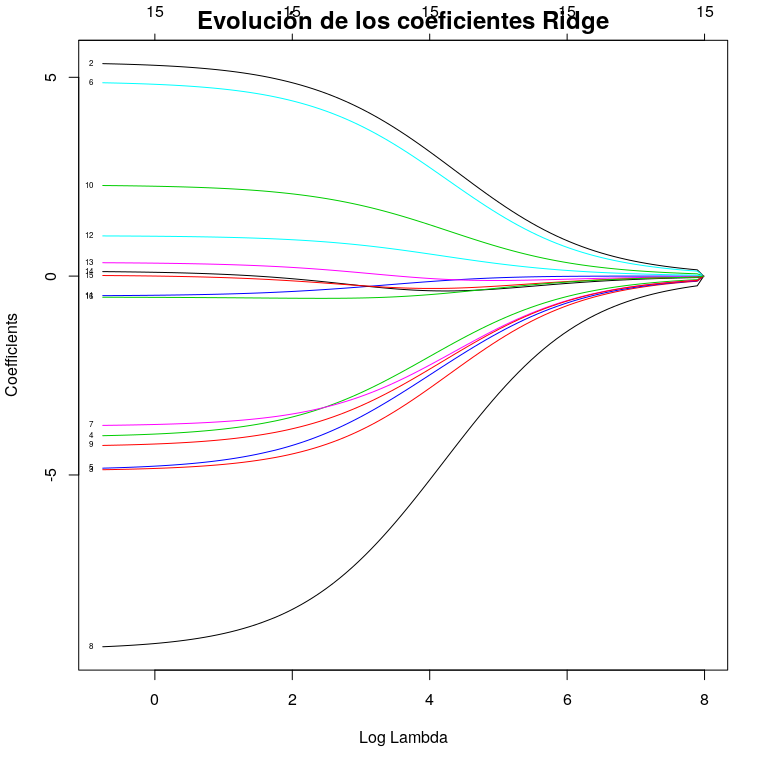

```r
#plot(ridge.mod)
plot(ridge.mod, xvar = "lambda", label = TRUE)
title(main = list("Evolución de los coeficientes Ridge",
                  cex = 1.5, col = "black", font = 10))
```

```r
NA
NA
```

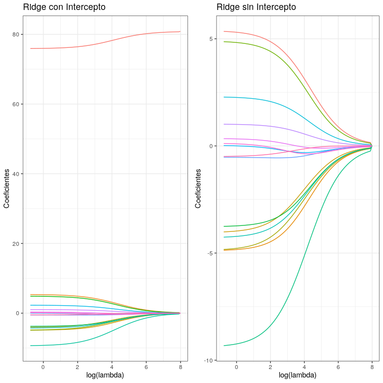

```r
g1=ridge_coef  %>% ggplot(., aes(log(lambda), estimate, group=term, color=term)) + geom_line() + theme_bw()  + theme(legend.position = 'none') +
  labs(title="Ridge con Intercepto",  y="Coeficientes")

g2=ridge_coef %>% filter(term!='(Intercept)') %>%
  ggplot(., aes(log(lambda), estimate, group=term, color=term)) + geom_line() + theme_bw()  + theme(legend.position = 'none') +
  labs(title="Ridge sin Intercepto", y="Coeficientes")

plot_grid(g1,g2)
```

### Elección lambda óptimo

```r
ridge_cv=cv.glmnet(x=prod_mtx,y=prod_precios,alpha=0, standardize = T)
```

```
integer(0)
```

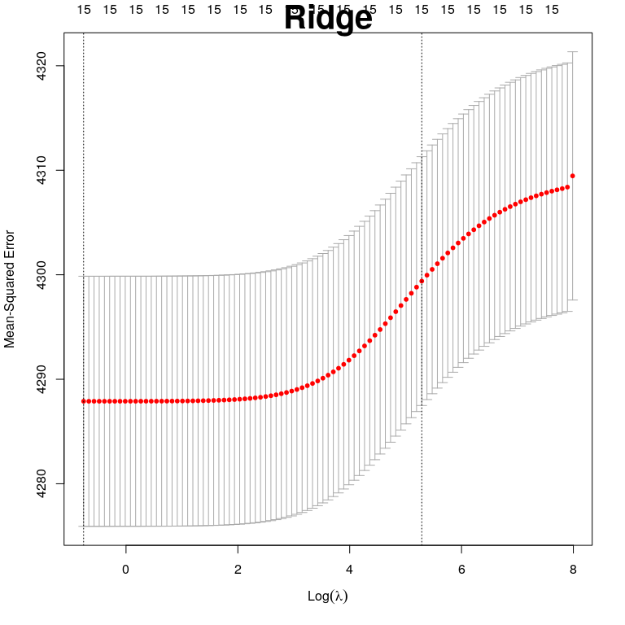

```r
plot(ridge_cv)+
  title(main = list("Ridge",
                  cex = 2.5, col = "black", font = 10))
```

```r
# Selección lambda óptimo
lasso_cv %>% glance()
```

| lambda.min | lambda.1se | nobs |
| --- | --- | --- |
| 0.01935577 | 2.442421 | 1146554 |

```r
NA
```